# Recommendation System

### Context

During the last few decades, with the rise of Youtube, Amazon, Netflix and many other such web services, recommender systems have taken more and more place in our lives. From e-commerce (suggest to buyers articles that could interest them) to online advertisement (suggest to users the right contents, matching their preferences), recommender systems are today unavoidable in our daily online journeys.

In a very general way, recommender systems are algorithms aimed at suggesting relevant items to users (items being movies to watch, text to read, products to buy or anything else depending on industries).

Recommender systems are really critical in some industries as they can generate a huge amount of income when they are efficient or also be a way to stand out significantly from competitors. As a proof of the importance of recommender systems, we can mention that, a few years ago, Netflix organised a challenges (the “Netflix prize”) where the goal was to produce a recommender system that performs better than its own algorithm with a prize of 1 million dollars to win.

**(Baptiste Rocca - Towards Data Science)**

Data source: https://www.kaggle.com/datasets/hernan4444/anime-recommendation-database-2020

# Collaborative Filtering

```python
#Import SparkSession, pyspark
import pyspark
from pyspark.sql import SparkSession

#Create SparkSession
spark = SparkSession.builder \
      .master("local[1]") \
      .appName("test") \
      .getOrCreate()
```

```python
import os
import pandas as pd
pd.set_option('display.max_column', None)
pd.set_option('display.max_row', None)
import numpy as np

from pyspark import SparkConf, SparkContext
from pyspark.sql import SparkSession, SQLContext

from pyspark.sql.types import *
import pyspark.sql.functions as F
from pyspark.sql.functions import udf, col

from pyspark.ml.recommendation import ALS
from pyspark.mllib.evaluation import RegressionMetrics

from pyspark.ml.evaluation import RegressionEvaluator
```

```python
#Import Data
data_schema = StructType([
    StructField("userID", IntegerType(), False),
    StructField("animeID", IntegerType(), False),
    StructField("rating", IntegerType(), True)
])

#Import rating data
data = spark.read.csv("C:/Users/admin/OneDrive/Máy tính/Python Project/Ratings.csv", header=True, schema=data_schema)

#Import anime information data
anime_spark = spark.read.csv("C:/Users/admin/OneDrive/Máy tính/Python Project/Portfolio/anime.csv", header=True)\
                    .select(col("MAL_ID").cast('int').alias("animeID"), col("Name").cast(StringType()).alias("name"), col("Type").cast(StringType()).alias("type"))

#Only select movie and TV series
data = data.join(anime_spark, 'animeID', 'left').filter((col("type")=='TV') | (col("type")=='Movie')).select(col("userID"), col("animeID"), col("rating"))
```

```python
data.show(5)
```

```
+------+-------+------+
|userID|animeID|rating|
+------+-------+------+
|     0|    430|     9|
|     0|   3010|     7|
|     0|    570|     7|
|     0|   2762|     9|
|     0|    431|     8|
+------+-------+------+
only showing top 5 rows
```

```python
data.filter("userID IS NULL OR animeID IS NULL OR rating IS NULL").show()
```

```
+------+-------+------+
|userID|animeID|rating|
+------+-------+------+
+------+-------+------+
```

```python
data.printSchema()
```

```
root
 |-- userID: integer (nullable = true)
 |-- animeID: integer (nullable = true)
 |-- rating: integer (nullable = true)
```

- The original data is already in a long table format, which is required for ALS to work.
- The userID and animeID are integer.
- There are no missing values.  
  --> The data is clean and ready to fit into the ALS.

```python
#Calculating Sparsity (Sparsity = Number of ratings in Matrix/Size of the Matrix)
#Number of Ratings in Matrix
numerator = data.count()

#Size of the Matrix
users = data.select("userID").distinct().count()
anime = data.select("animeID").distinct().count()
denominator = users*anime

#Sparsity
sparsity = 1 - (numerator*1.0/denominator)
print("Sparsity: "), sparsity
```

```
Sparsity:
```

```
(None, 0.9804341959901998)
```

The matrix has Sparsity approximately = 1, meaning that the matrix has many missing values, which is normal since a user can only watch a small proportion of the total anime available.

```python
#BUILDING ALS MODEL
#Split data
(train, test) = data.randomSplit([0.8, 0.2])

#Evaluation using RMSE
evaluator = RegressionEvaluator(metricName='rmse', labelCol='rating', predictionCol='prediction')

#ALS model
als = ALS(userCol='userID', itemCol='animeID', ratingCol='rating',
         coldStartStrategy='drop', nonnegative=True, implicitPrefs=False,
         rank=20, maxIter=10, regParam=0.1) #The Ratings of anime are explicit ratings
model = als.fit(train)

#Predict
predictions = model.transform(test)
rmse = evaluator.evaluate(predictions)

#Print result
print("RMSE = "), rmse
```

```
RMSE =
```

```
(None, 1.1458285578541652)
```

- RMSE is approximately 1, indicating a difference of about 1 points in predictions on a 10-point scale, which is a quite good score.
- Also, If we can use CrossValidator to tune hyperparameters then the model's performance will improve even more.

```python
#Output recommendations
#Generate top 10 anime recommendations for each user
userRecs = model.recommendForAllUsers(10)
userRecs.show(5)
```

```
+------+--------------------+
|userID|     recommendations|
+------+--------------------+
|    12|[{31696, 11.01106...|
|    22|[{41674, 10.50373...|
|    27|[{8189, 9.593988}...|
|    28|[{28023, 10.37557...|
|    31|[{4181, 10.513002...|
+------+--------------------+
only showing top 5 rows
```

Here we can see that the output is hard to read so we will need to make the output more human-readable by cleaning it.

```python
#Cleaning recommendations output
userRecs.registerTempTable("userRecs_temp")

clean_Recs = spark.sql("SELECT userID, animeID_and_rating.animeID AS animeID, animeID_and_rating.rating AS prediction\
                       FROM userRecs_temp\
                       LATERAL VIEW explode(recommendations) exploded_table\
                       AS animeID_and_rating")
clean_Recs.show(10)
```

```
+------+-------+----------+
|userID|animeID|prediction|
+------+-------+----------+
|    12|  31696| 11.011063|
|    12|   8189| 10.966456|
|    12|  40748| 10.775541|
|    12|   5114| 10.413926|
|    12|  33319| 10.409966|
|    12|  28023| 10.391126|
|    12|  41911| 10.378758|
|    12|  32281| 10.334861|
|    12|   6702|10.3109665|
|    12|   2904| 10.291434|
+------+-------+----------+
only showing top 10 rows
```

- Here the result is readable and looks neat. However, we can see that there are some records showing that the model is giving a predicted rating that is higher than the rating range (0-10). However, as far as I know, this is not the model's error and this could give us extra information about how much stronger than 10 the predicted rating is. Based on analyzing records with scores higher than 10 or lower than 0 (if any), we can find more insights about each user's preferences.
- The next problem is that the recommendations include the anime that has been watched. Since the ALS factorization the matrix into 2 matrices with full values, it will make recommendations based on all anime. We must filter anime that has been watched by each user.

```python
#Filtering only unwatched anime
clean_Recs.join(data, ['userID', 'animeID'], 'left').filter(data.rating.isNull()).show(10)
```

```
+------+-------+----------+------+
|userID|animeID|prediction|rating|
+------+-------+----------+------+
|     3|  31696|  9.323527|  null|
|     4|  32281|  8.646853|  null|
|     6|  31463|  8.882861|  null|
|     6|  33894|  8.867509|  null|
|     7|   9253|  8.971895|  null|
|     8|    572|  8.219286|  null|
|    10|  11741|  8.793772|  null|
|    12|   8189| 10.966456|  null|
|    13|   7311|  9.005111|  null|
|    14|  33894|  9.290343|  null|
+------+-------+----------+------+
only showing top 10 rows
```

So we have the complete results of each user's predicted rating as well as we can arbitrarily view the top n anime series that the system recommends for each user.  
Next I'll see what recommendations ALS makes for a specific user. I will select a random userID and see the unwatched anime recommendations for that user.

```python
#Random choosing a user (1956)
data.join(anime_spark, on='animeID', how='left').filter((data.userID==1956) & (data.rating==10)).show(5, False)
```

```
+-------+------+------+----------------------------------------------------------+----+
|animeID|userID|rating|name                                                      |type|
+-------+------+------+----------------------------------------------------------+----+
|2904   |1956  |10    |Code Geass: Hangyaku no Lelouch R2                        |TV  |
|1535   |1956  |10    |Death Note                                                |TV  |
|31043  |1956  |10    |Boku dake ga Inai Machi                                   |TV  |
|37999  |1956  |10    |Kaguya-sama wa Kokurasetai: Tensai-tachi no Renai Zunousen|TV  |
|34126  |1956  |10    |Rewrite 2nd Season                                        |TV  |
+-------+------+------+----------------------------------------------------------+----+
only showing top 5 rows
```

```python
#Recommendations for user 1956
clean_Recs.join(data, ['userID', 'animeID'], 'left').join(anime_spark, 'animeID', 'left').filter((data.rating.isNull()) & (clean_Recs.userID==1956)).show(10, False)
```

```
+-------+------+----------+------+------------------------------------------------------+-----+
|animeID|userID|prediction|rating|name                                                  |type |
+-------+------+----------+------+------------------------------------------------------+-----+
|4181   |1956  |8.623147  |null  |Clannad: After Story                                  |TV   |
|9253   |1956  |8.747759  |null  |Steins;Gate                                           |TV   |
|30484  |1956  |8.603921  |null  |Steins;Gate 0                                         |TV   |
|31696  |1956  |9.181666  |null  |Witch Village Story                                   |TV   |
|32281  |1956  |8.782782  |null  |Kimi no Na wa.                                        |Movie|
|33352  |1956  |8.644143  |null  |Violet Evergarden                                     |TV   |
|36167  |1956  |8.672453  |null  |Yuhuwa Chingudeul                                     |TV   |
|38329  |1956  |8.61923   |null  |Seishun Buta Yarou wa Yumemiru Shoujo no Yume wo Minai|Movie|
|40748  |1956  |9.020134  |null  |Jujutsu Kaisen (TV)                                   |TV   |
+-------+------+----------+------+------------------------------------------------------+-----+
```

For someone who likes Death Note and Kaguya-sama, the system's recommendations are quite good, personally I think options like Jujutsu Kaisen, Kimi no Na wa, Steins;Gate and Seishun Buta are very good choices.

### Conclusion

Collaborative Filtering Recommendations will be very effective in suggesting new options to users from many different perspectives of other users instead of just based on that user's perspective. However, this algorithm has low personalization, not based on the user's personal preferences such as liking the action genre, detective, etc.

# Content-based Recommendation

Content-based Recommendation is based on object properties such as genre, release year, producer, etc. Content-based recommendation is more personal and can be relied on to build a recommendation system for even new products based on the properties of the product without depending on the reviews of other users.

In this part, I will build a recommendation system based on information about the genre, year of production and overview of the anime's content. This model is based on my hypothesis that instead of just relying on an overview of the anime's content, if combined with the genre of the movie, we will have a more effective model.

For example, if two anime series have different genres, with an anime like "Cowboy Bebop" talking about Sci-fi, space and action versus "Chibikko Cowboy" - a music video anime for children with a music theme, it's clear that these two anime won't be compatible with each other. However, because both have the same description of "Cowboy", Tf-idf will produce a cosine similarity distance between these two anime that is very close.

So for genre, release year, rating and type, I will use CountVectorizer and from there use KMeans Clustering to group anime series with similar genre, release year, rating and type together into one cluster. And recommendation will only produce results between anime series in the same cluster.

```python
import nltk
import re
from nltk.stem.snowball import SnowballStemmer
from sklearn.feature_extraction.text import CountVectorizer, TfidfVectorizer
from sklearn.metrics.pairwise import cosine_similarity
```

```python
#Import data
anime = pd.read_csv("C:/Users/admin/OneDrive/Máy tính/Python Project/Portfolio/anime.csv")
synopsis = pd.read_csv("C:/Users/admin/OneDrive/Máy tính/Python Project/Portfolio/anime_with_synopsis.csv")
df = anime.merge(synopsis, on="MAL_ID", suffixes=('', '_y'))
df = df[['Name', 'Genres', 'sypnopsis', 'Aired', 'Type','Rating']]

# Data Cleaning
df = df.drop_duplicates(subset=['Name']).dropna()
df = df[(df['Genres']!='Unknown') & (df['Aired']!='Unknown') & (df['Rating']!='Unknown') & (df['Type']!='Unknown')]
df = df[(df['Type']=='TV') | (df['Type']=='Movie')]

#Data Transformation
df['Year'] = df['Aired'].apply(lambda x: x[-4:] if x[-4:].isdigit() else x[-9:-5]) #Extract Year from 'Aired' column
df['Decade'] = df['Year'].apply(lambda x: '80s' if 1980<=int(x)<1990 else '90s' if 1990<=int(x)<2000 else '2000s' if 2000<=int(x)<2010 else '2010s' if 2010<=int(x) else 'Other') #Convert the publish year into decade
df['Rating'] = df['Rating'].apply(lambda x: re.sub(r"[\s\-\+\&()]", '', x))
df['Tags'] = df['Genres'] + ', ' + df['Rating'] + ', ' + df['Decade'] + ', ' + df['Type']
df = df.drop(['Aired', 'Year'], axis=1)

df.head()
```

|  | Name | Genres | sypnopsis | Type | Rating | Decade | Tags |
| --- | --- | --- | --- | --- | --- | --- | --- |
| 0 | Cowboy Bebop | Action, Adventure, Comedy, Drama, Sci-Fi, Space | In the year 2071, humanity has colonized sever... | TV | R17violenceprofanity | 90s | Action, Adventure, Comedy, Drama, Sci-Fi, Spac... |
| 1 | Cowboy Bebop: Tengoku no Tobira | Action, Drama, Mystery, Sci-Fi, Space | other day, another bounty—such is the life of ... | Movie | R17violenceprofanity | 2000s | Action, Drama, Mystery, Sci-Fi, Space, R17viol... |
| 2 | Trigun | Action, Sci-Fi, Adventure, Comedy, Drama, Shounen | Vash the Stampede is the man with a $$60,000,0... | TV | PG13Teens13orolder | 90s | Action, Sci-Fi, Adventure, Comedy, Drama, Shou... |
| 3 | Witch Hunter Robin | Action, Mystery, Police, Supernatural, Drama, ... | ches are individuals with special powers like ... | TV | PG13Teens13orolder | 2000s | Action, Mystery, Police, Supernatural, Drama, ... |
| 4 | Bouken Ou Beet | Adventure, Fantasy, Shounen, Supernatural | It is the dark century and the people are suff... | TV | PGChildren | 2000s | Adventure, Fantasy, Shounen, Supernatural, PGC... |

```python
# Create an English language SnowballStemmer object
stemmer = SnowballStemmer("english")

# Define a function to perform both stemming and tokenization
def tokenize_and_stem(text):
    # Tokenize by sentence, then by word - perform tokenization (splitting token)
    tokens = [word for sent in nltk.sent_tokenize(text)
              for word in nltk.word_tokenize(sent)]
    # Filter out raw tokens to remove noise - token normalization
    filtered_tokens = [token for token in tokens if re.search('[a-zA-Z]', token)]
    # Stem the filtered_tokens
    stems = [stemmer.stem(word) for word in filtered_tokens]
    return stems
```

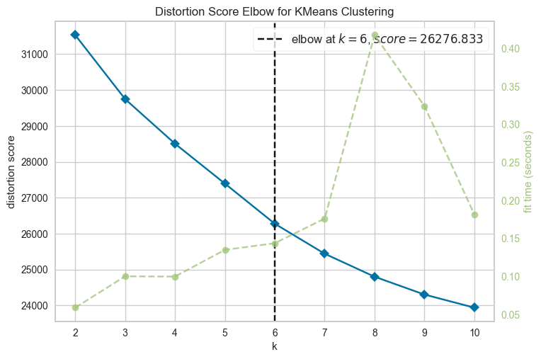

```python
#Create count matrix based on genres
count_vectorizer = CountVectorizer(stop_words='english', ngram_range=(1, 1), tokenizer=tokenize_and_stem, binary=True)
count_matrix = count_vectorizer.fit_transform(df['Tags'])
count_df = pd.DataFrame(data=count_matrix.A, columns=count_vectorizer.get_feature_names_out())

#Finding elbow of KMean
from sklearn.cluster import KMeans
from yellowbrick.cluster import KElbowVisualizer
Elbow_M = KElbowVisualizer(KMeans(), k=10, metric='distortion')
Elbow_M.fit(count_df)
Elbow_M.show()
```

```python
#Fitting KMeans Model
model = KMeans(n_clusters=6)
model.fit(count_df)
count_df['Cluster'] = model.fit_predict(count_df)

#Assigning Cluster number to the original df
df['Cluster'] = count_df.Cluster

#Evaluate model
from sklearn.metrics import silhouette_score
silhouette_avg = silhouette_score(count_df.drop(['Cluster'], axis=1), count_df['Cluster'])
print("Silhouette Coefficient:", silhouette_avg)
```

```
Silhouette Coefficient: 0.09913930918851563
```

Here, we see that the Silhouette Coefficient is quite low because our input data is high-dimensional data. Due to the "curse of dimensionality", KMeans will be less effective for high-dimensional data. So I'll try using PCA to see if we can get a better result.

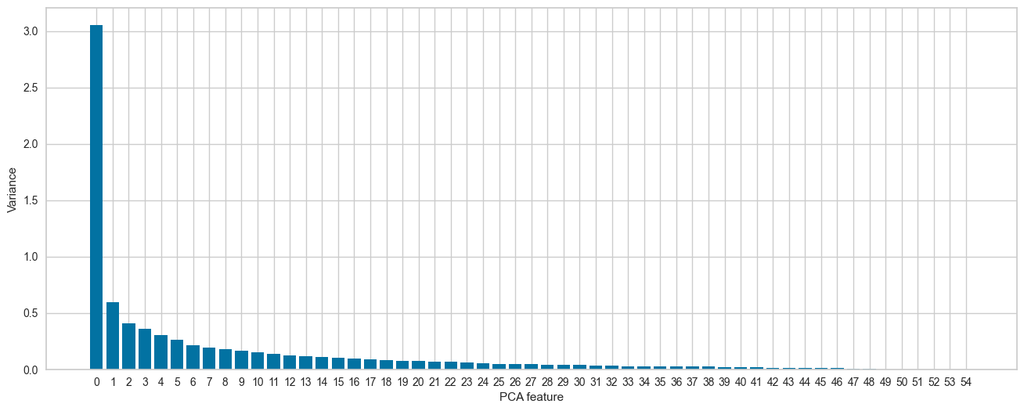

```python
import matplotlib.pyplot as plt
from sklearn.decomposition import PCA
pca = PCA()
pca.fit(count_df)
features = range(pca.n_components_)

#Visualize PCA feature
plt.figure(figsize=(16, 6))
plt.bar(features, pca.explained_variance_)
plt.xticks(features)
plt.ylabel('Variance')
plt.xlabel('PCA feature')
plt.show()
```

```
Maximum value of Silhouette Score: 0.10593707295434238
Value of n: 16
Elbow Value: 6
```

[figure not shown]

```python
silhouette = []
n_value = []
elbow_value = []

for n in range(5, 40):
    n_value.append(n)
    pca = PCA(n_components=n, svd_solver='full')
    count_array_transformed = pca.fit_transform(count_df.drop(['Cluster'], axis=1))

    #Fitting KElbow
    Elbow_M = KElbowVisualizer(KMeans(), k=10, metric='distortion')
    Elbow_M.fit(count_array_transformed)
    elbow_value.append(Elbow_M.elbow_value_)

    #Fitting KMeans Model
    kmean = KMeans(n_clusters=Elbow_M.elbow_value_, random_state=100)
    count_df['Cluster'] = kmean.fit_predict(count_array_transformed)

    #Calculate silhouette score
    silhouette.append(silhouette_score(count_df.drop(['Cluster'], axis=1), count_df['Cluster']))

print("Maximum value of Silhouette Score: {}\nValue of n: {}\nElbow Value: {}"
      .format(max(silhouette), n_value[silhouette.index(max(silhouette))], elbow_value[silhouette.index(max(silhouette))]))
```

Silhouette Score improved a little after applying PCA.

```python
#Fitting KMeans Model
pca = PCA(n_components=16, svd_solver='full')
count_array_transformed = pca.fit_transform(count_df.drop(['Cluster'], axis=1))

#Fitting KMeans Model
kmean = KMeans(n_clusters=6, random_state=100)
count_df['Cluster'] = kmean.fit_predict(count_array_transformed)

#Assigning Cluster number to the original df
df['Cluster'] = count_df.Cluster

#Calculate silhouette score
print("Silhouette Coefficient: ", silhouette_score(count_df.drop(['Cluster'], axis=1), count_df['Cluster']))
```

```
Silhouette Coefficient:  0.10593707295434238
```

```python
# Instantiate TfidfVectorizer object with stopwords and tokenizer
tfidf_vectorizer = TfidfVectorizer(max_df=0.8, ngram_range=(1, 2), stop_words='english', tokenizer=tokenize_and_stem)

# Fit and transform the tfidf_vectorizer
tfidf_matrix = tfidf_vectorizer.fit_transform([x for x in df["sypnopsis"]])

#Output the shape of tfidf_matrix
tfidf_matrix.shape
```

```
(7501, 286991)
```

```python
# Calculate the similarity distance
similarity_distance = 1 - cosine_similarity(tfidf_matrix)

#Create a df from the similarity matrix
vals = df.Name.tolist()
similarity_df = pd.DataFrame(similarity_distance, columns=vals, index=vals)
similarity_df['Cluster'] = df.set_index('Name').Cluster

#Print first 5
similarity_df.head()
```

|  | Cowboy Bebop | Cowboy Bebop: Tengoku no Tobira | Trigun | Witch Hunter Robin | Bouken Ou Beet | Eyeshield 21 | Hachimitsu to Clover | Hungry Heart: Wild Striker | Initial D Fourth Stage | Monster | Naruto | One Piece | Tennis no Ouji-sama | Ring ni Kakero 1 | School Rumble | Sunabouzu | Texhnolyze | Trinity Blood | Yakitate!! Japan | Zipang | Neon Genesis Evangelion | Neon Genesis Evangelion: Death & Rebirth | Neon Genesis Evangelion: The End of Evangelion | Kenpuu Denki Berserk | Koukaku Kidoutai | Rurouni Kenshin: Meiji Kenkaku Romantan | Rurouni Kenshin: Meiji Kenkaku Romantan - Ishinshishi e no Chinkonka | Akira | .hack//Sign | … |
| --- | --- | --- | --- | --- | --- | --- | --- | --- | --- | --- | --- | --- | --- | --- | --- | --- | --- | --- | --- | --- | --- | --- | --- | --- | --- | --- | --- | --- | --- | --- |
| Cowboy Bebop | 0.000000 | 9.019173e-01 | 9.814684e-01 | 0.992948 | 9.945422e-01 | 0.986127 | 0.998681 | 0.994963 | 0.992426 | 0.994832 | 0.997839 | 0.988441 | 0.987743 | 0.997309 | 0.991727 | 0.995928 | 0.990943 | 0.988502 | 0.996485 | 0.983962 | 0.990260 | 0.995552 | 0.989317 | 0.993525 | 0.991478 | 0.993738 | 0.998425 | 0.996561 | 0.995302 | … |
| Cowboy Bebop: Tengoku no Tobira | 0.901917 | -2.220446e-16 | 9.911122e-01 | 0.990698 | 9.977651e-01 | 0.988712 | 0.992629 | 0.993575 | 0.994483 | 0.993988 | 0.994956 | 0.989289 | 0.991579 | 1.000000 | 1.000000 | 0.993472 | 0.988342 | 0.989565 | 0.997000 | 0.979121 | 0.994188 | 0.997061 | 0.994788 | 0.990558 | 0.988748 | 0.997298 | 0.998035 | 0.989314 | 0.995205 | … |
| Trigun | 0.981468 | 9.911122e-01 | -4.440892e-16 | 0.999162 | 9.946235e-01 | 0.994157 | 0.998107 | 0.996570 | 0.999412 | 0.990394 | 0.992428 | 0.989073 | 0.992096 | 0.994805 | 0.994989 | 0.982278 | 0.989673 | 0.987791 | 0.997724 | 0.993864 | 0.992516 | 0.985397 | 0.996126 | 0.991957 | 0.972049 | 0.977801 | 0.997176 | 0.980873 | 0.995294 | … |
| Witch Hunter Robin | 0.992948 | 9.906977e-01 | 9.991620e-01 | 0.000000 | 9.980563e-01 | 0.989155 | 0.999548 | 0.996406 | 0.995541 | 0.996308 | 0.995423 | 0.995571 | 0.993659 | 0.992279 | 0.995869 | 0.994090 | 0.984618 | 0.994254 | 0.990706 | 0.997203 | 0.994626 | 0.997245 | 0.994492 | 0.995543 | 0.991461 | 0.997774 | 0.995717 | 0.987179 | 0.992172 | … |
| Bouken Ou Beet | 0.994542 | 9.977651e-01 | 9.946235e-01 | 0.998056 | -2.220446e-16 | 0.969561 | 0.998563 | 0.990637 | 0.995651 | 0.991710 | 0.983792 | 0.987093 | 0.993983 | 0.998056 | 0.997816 | 0.994737 | 0.990130 | 0.992447 | 0.994948 | 0.996104 | 0.987720 | 0.978709 | 0.993984 | 0.986712 | 0.992937 | 0.993017 | 0.996183 | 0.987383 | 0.998746 | … |

```python
#Recommendation example with same cluster
name = 'Death Note'

matches = similarity_df[similarity_df['Cluster']==similarity_df.loc[name, 'Cluster']][name].sort_values()[1:6]
matches = matches.index.tolist()
df.set_index('Name').loc[matches][['Genres', 'Type', 'Decade', 'Rating']]
```

| Name | Genres | Type | Decade | Rating |
| --- | --- | --- | --- | --- |
| Detective Conan Movie 09: Strategy Above the Depths | Adventure, Mystery, Comedy, Police, Shounen | Movie | 2000s | PG13Teens13orolder |
| Koukaku Kidoutai | Action, Mecha, Police, Psychological, Sci-Fi, ... | Movie | 90s | RMildNudity |
| Strike Witches | Action, Ecchi, Magic, Military, Sci-Fi | TV | 2000s | RMildNudity |
| Uchuu Kaizoku Mito no Daibouken | Action, Comedy, Sci-Fi | TV | 90s | PG13Teens13orolder |
| Psycho-Pass | Action, Sci-Fi, Police, Psychological | TV | 2010s | R17violenceprofanity |

```python
#Recommendation example without filter on cluster
name = 'Death Note'

matches = similarity_df[name].sort_values()[1:6]
matches = matches.index.tolist()
df.set_index('Name').loc[matches][['Genres', 'Type', 'Decade', 'Rating']]
```

| Name | Genres | Type | Decade | Rating |
| --- | --- | --- | --- | --- |
| Yami no Matsuei | Comedy, Drama, Fantasy, Horror, Magic, Shoujo,... | TV | 2000s | R17violenceprofanity |
| Shinigami no Ballad. | Drama, Fantasy, Psychological, Supernatural | TV | 2000s | PG13Teens13orolder |
| Soul Eater | Action, Fantasy, Comedy, Supernatural, Shounen | TV | 2000s | PG13Teens13orolder |
| YAT Anshin! Uchuu Ryokou 2 | Adventure, Comedy, Sci-Fi, Shounen | TV | 90s | PG13Teens13orolder |
| Hei Mao Jing Zhang (1992) | Action, Adventure, Cars, Comedy, Kids, Police | TV | 90s | PGChildren |

After trying the example with the anime "Death Note" - one of my favorite anime - I personally judge that **the results after filtering anime in the same cluster are better** than without filtering. As for the results purely based on synopsis, we see that TF-IDF's top 1 recommendation is "Yami no Matsuei" - a shoujo boy love anime series about the theme of death and is completely incompatible with "Death Note". These two anime series simply share the keyword "god of death" (shinigami) in the description.

For the movies recommended in the same cluster, I think the model's choices are quite good (Conan, Koukaku Kidoutai, and Psycho-Pass are all suitable anime).

```python
#Recommendation example with same cluster
name = 'Steins;Gate'

matches = similarity_df[similarity_df['Cluster']==similarity_df.loc[name, 'Cluster']][name].sort_values()[:6]
matches = matches.index.tolist()
df.set_index('Name').loc[matches][['Genres', 'Type', 'Decade', 'Rating']]
```

| Name | Genres | Type | Decade | Rating |
| --- | --- | --- | --- | --- |
| Steins;Gate | Thriller, Sci-Fi | TV | 2010s | PG13Teens13orolder |
| Mousou Kagaku Series: Wandaba Style | Comedy, Sci-Fi | TV | 2000s | PG13Teens13orolder |
| Seikimatsu Occult Gakuin | Sci-Fi, Mystery, Comedy, Supernatural, School | TV | 2010s | R17violenceprofanity |
| Tsumiki no Ie | Drama | Movie | 2000s | GAllAges |
| Nanako SOS | Comedy, Parody, Romance, Super Power | TV | 80s | GAllAges |
| Keroro Gunsou Movie 3: Tenkuu Daikessen de Arimasu! | Comedy, Sci-Fi, Shounen | Movie | 2000s | PGChildren |

```python
#Recommendation example without filter on cluster
name = 'Steins;Gate'

matches = similarity_df[name].sort_values()[:6]
matches = matches.index.tolist()
df.set_index('Name').loc[matches][['Genres', 'Type', 'Decade', 'Rating']]
```

| Name | Genres | Type | Decade | Rating |
| --- | --- | --- | --- | --- |
| Steins;Gate | Thriller, Sci-Fi | TV | 2010s | PG13Teens13orolder |
| Steins;Gate 0 | Sci-Fi, Thriller | TV | 2010s | PG13Teens13orolder |
| Steins;Gate Movie: Fuka Ryouiki no Déjà vu | Sci-Fi, Drama | Movie | 2010s | PG13Teens13orolder |
| Tabisuru Nuigurumi: Traveling Daru | Kids, Slice of Life | Movie | 2010s | GAllAges |
| Mousou Kagaku Series: Wandaba Style | Comedy, Sci-Fi | TV | 2000s | PG13Teens13orolder |
| Clannad: After Story | Slice of Life, Comedy, Supernatural, Drama, Ro... | TV | 2000s | PG13Teens13orolder |

However, this model also has disadvantages. When testing with "Steins;Gate" (also another favorite anime of mine), **the results without filter on cluster are better** than in the same cluster because it includes the other 2 parts of "Steins;Gate " are "Steins;Gate 0" and "Steins;Gate Movie".

### Conclusion

In testing this model, I found that clustering was quite difficult and gave a quite low Silhouette Score, as well as the choices in the same cluster were not optimal. In addition, this method will not work for anime series with unclear themes and genre tags. However, when there is no information about other users' choices and reviews, Content-based Recommendation will definitely be a great choice to find suitable anime series!!